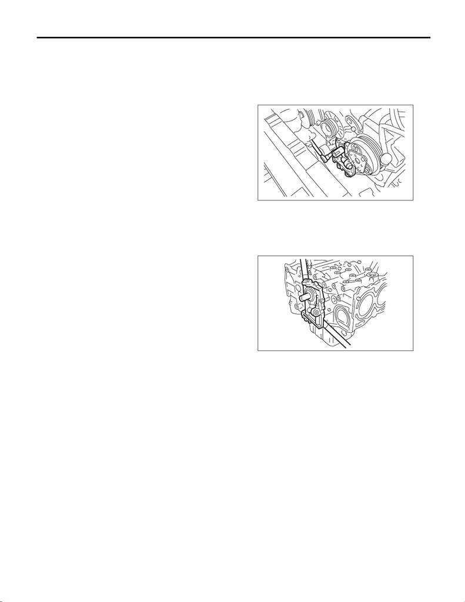

ME(STI)-80

Cylinder Block

MECHANICAL

20.Cylinder Block

A: REMOVAL

NOTE:

Before conducting this procedure, drain the engine

oil completely.

1) Remove the engine from the vehicle. <Ref. to

ME(STI)-30, REMOVAL, Engine Assembly.>

2) Remove the rear side belt. <Ref. to ME(STI)-41,

REAR SIDE BELT, REMOVAL, V-belt.>

3) Remove the intake manifold. <Ref. to FU(STI)-

17, REMOVAL, Intake Manifold.>

4) Remove the crank pulley. <Ref. to ME(STI)-48,

REMOVAL, Crank Pulley.>

5) Remove the timing belt cover. <Ref. to ME(STI)-

50, REMOVAL, Timing Belt Cover.>

6) Remove the timing belt. <Ref. to ME(STI)-51,

REMOVAL, Timing Belt.>

7) Remove the cam sprocket. <Ref. to ME(STI)-60,

REMOVAL, Cam Sprocket.>

8) Remove the crank sprocket. <Ref. to ME(STI)-

61, REMOVAL, Crank Sprocket.>

9) Remove the generator and A/C compressor with

their brackets.

10) Remove the camshaft. <Ref. to ME(STI)-62,

REMOVAL, Camshaft.>

11) Remove the cylinder head. <Ref. to ME(STI)-

70, REMOVAL, Cylinder Head.>

12) Remove the clutch disc and cover. <Ref. to CL-

12, REMOVAL, Clutch Disc and Cover.>

13) Remove the flywheel. <Ref. to CL-15, REMOV-

AL, Flywheel.>

14) Remove the oil separator cover.

15) Remove the water by-pass pipe for heater.

16) Remove the oil filter. <Ref. to LU(STI)-29, RE-

MOVAL, Engine Oil Filter.>

17) Remove the oil cooler. <Ref. to LU(STI)-23,

REMOVAL, Engine Oil Cooler.>

18) Remove the water pump. <Ref. to CO(STI)-15,

REMOVAL, Water Pump.>

19) Remove the bolts which secure oil pump to cyl-

inder block.

NOTE:

When disassembling and checking the oil pump,

loosen the relief valve plug before removing the oil

pump.

20) Remove the oil pump from cylinder block using

a crowbar.

CAUTION:

Be careful not to scratch the mating surface of

the cylinder block and oil pump.

21) Remove the front oil seal from the oil pump.

22) Remove the oil pan.

(1) Set the part so that the cylinder block LH is

on the upper side.

(2) Remove the bolts which secure oil pan to

cylinder block.

(3) Insert an oil pan cutter blade between cylin-

der block-to-oil pan clearance and remove the

oil pan.

CAUTION:

Do not use a screwdriver or similar tools in

place of oil pan cutter.

23) Remove the oil strainer.

24) Remove the baffle plate.

LU-00015

LU-03222

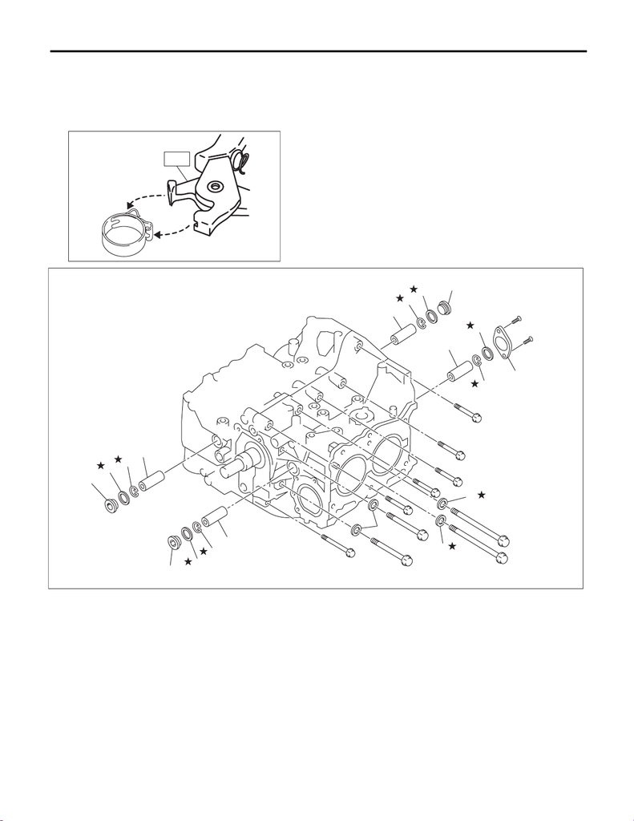

ME(STI)-81

Cylinder Block

MECHANICAL

25) Remove the water tank pipe assembly from the cylinder block RH.

NOTE:

Pinch the clamp of the water tank pipe assembly by fitting the cut out in the ST with the protrusion on the

clamp as shown in the figure, and unlock the clamp.

ST 18353AA000 CLAMP PLIERS

ME-04374

ST

(1) Service hole plug (4) Piston pin (7) Seal washer

(2) Gasket (5) Service hole cover (8) Washer

(3) Snap ring (6) O-ring

ME-04723

(3)

(4)

(2)

(1)

(3)

(4)

(5)

(6)

(2)

(3)

(2)

(1)

(3)

(4)

(4)

(8)

(7)

(1)

(7)

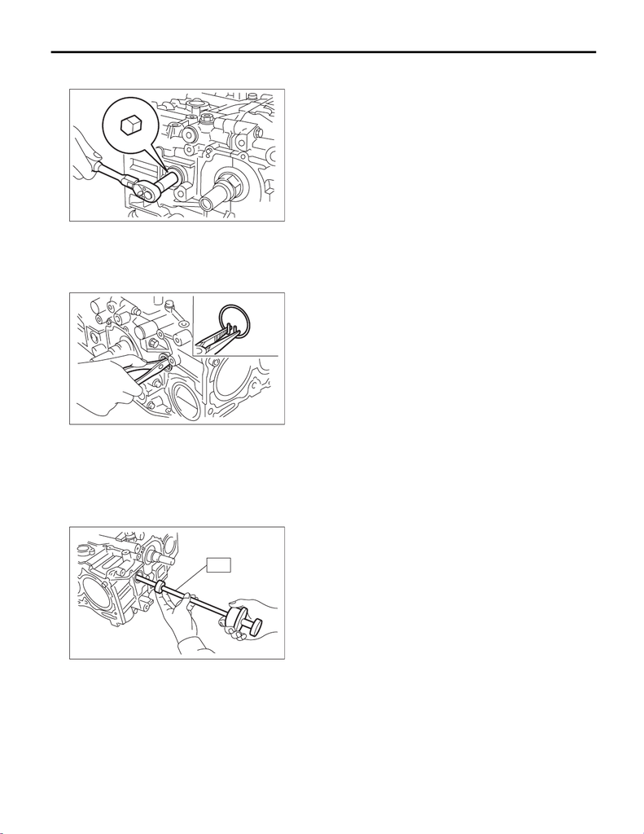

ME(STI)-82

Cylinder Block

MECHANICAL

26) Remove the service hole plugs using a hexa-

gon wrench [14 mm].

27) Remove the service hole cover.

28) Rotate the crankshaft to bring #1 and #2 pis-

tons to bottom dead center position, then remove

the piston snap ring through service hole of #1 and

#2 cylinders.

29) Draw out the piston pin from #1 and #2 pistons

using ST.

ST 499097700 PISTON PIN REMOVER

ASSY

NOTE:

Be careful not to confuse the original combination

of piston, piston pin and cylinder.

30) Similarly draw out the piston pins from #3 and

#4 pistons.

31) Remove the cylinder block connecting bolt on

the RH side.

32) Loosen the cylinder block connecting bolt on

the LH side by 2 to 3 turns.

33) Set the part so that the cylinder block LH is on

the upper side, and remove the cylinder block con-

necting bolt.

ME-00140

ME-00141

ME-03325

ST

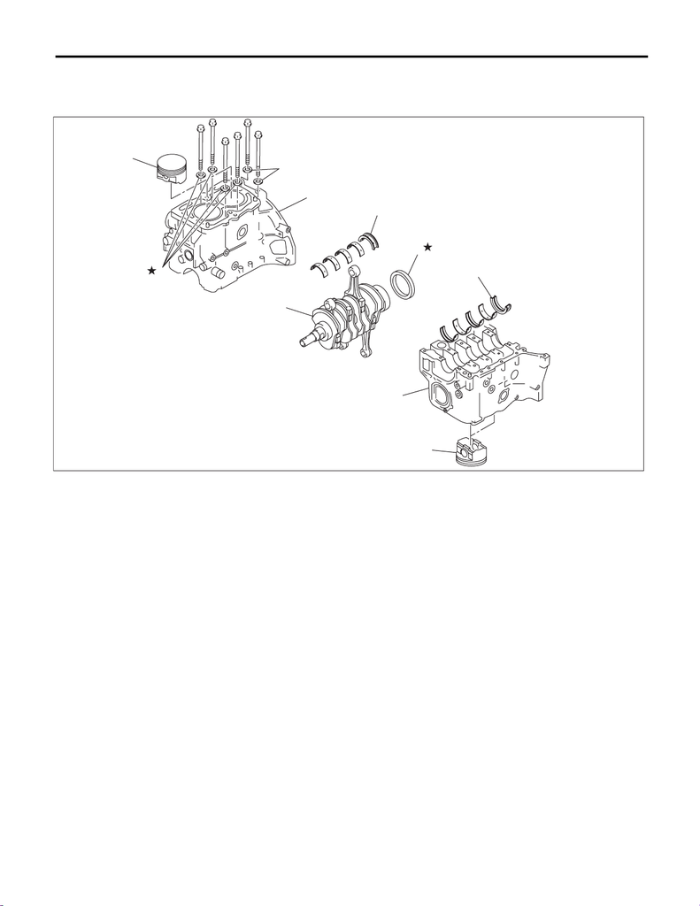

ME(STI)-83

Cylinder Block

MECHANICAL

34) Separate the cylinder block LH and RH.

NOTE:

When separating the cylinder block, do not allow the connecting rod to fall or damage the cylinder block.

35) Remove the rear oil seal.

36) Remove the crankshaft together with connecting rod.

37) Remove the crankshaft bearings from cylinder block using a hammer handle.

NOTE:

• Press the crankshaft bearing at the end opposite to locking lip to remove.

• Be careful not to confuse the crankshaft bearing combination.

38) Remove each piston from the cylinder block using a wooden bar or hammer handle.

NOTE:

Be careful not to confuse the original combination of piston and cylinder.

(1) Cylinder block (4) Crankshaft bearing (6) Seal washer

(2) Rear oil seal (5) Piston (7) Washer

(3) Crankshaft

ME-04724

(2)

(3)

(4)

(4)

(5)

(6)

(5)

(1)

(1)

(7)

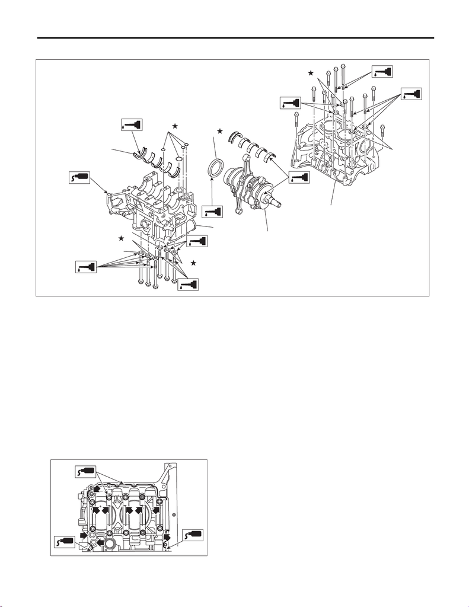

ME(STI)-84

Cylinder Block

MECHANICAL

B: INSTALLATION

1) Remove oil on the mating surface of cylinder block before installation. Apply a coat of engine oil to the

bearing and crankshaft journal.

2) Position the crankshaft and O-ring on cylinder block RH.

NOTE:

Use new O-rings.

3) Apply liquid gasket to the mating surfaces of cylinder block RH, and position cylinder block LH.

NOTE:

• Install within 5 min. after applying liquid gasket.

• Do not allow liquid gasket to jut into O-ring grooves, oil passages, bearing grooves, etc.

Liquid gasket:

THREE BOND 1217G (Part No. K0877Y0100) or equivalent

(1) Crankshaft bearing (4) Rear oil seal (6) Seal washer

(2) Crankshaft (5) O-ring (7) Washer

(3) Cylinder block

ME-04725

(4)

(1)

(3)

(6)

(6)

(7)

(7)

(3)

(2)

(5)

(6)

(7)

ME-00145

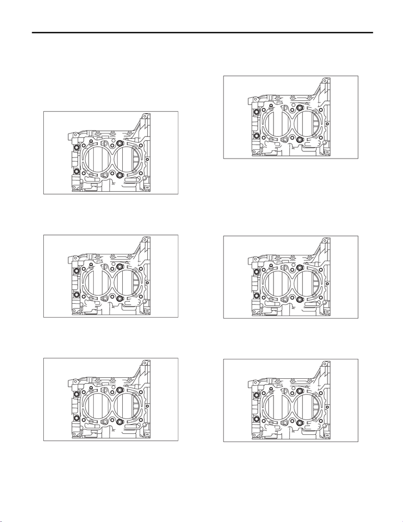

ME(STI)-85

Cylinder Block

MECHANICAL

4) Apply a coat of engine oil to the washer and bolt

thread.

NOTE:

Use a new seal washer.

5) Tighten the 10 mm cylinder block connecting

bolts on the LH side (A — D) in alphabetical order.

Tightening torque:

10 N·m (1.0 kgf-m, 7.4 ft-lb)

6) Tighten the 10 mm cylinder block connecting

bolts on the RH side (E — J) in alphabetical order.

Tightening torque:

10 N·m (1.0 kgf-m, 7.4 ft-lb)

7) Tighten the LH side cylinder block connecting

bolts (A — D) further in alphabetical order.

Tightening torque:

18 N·m (1.8 kgf-m, 13.3 ft-lb)

8) Tighten the RH side cylinder block connecting

bolts (E — J) further in alphabetical order.

Tightening torque:

18 N·m (1.8 kgf-m, 13.3 ft-lb)

9) Tighten the LH side cylinder block connecting

bolts (A — D) further in alphabetical order.

• (A), (C): Angle tightening

Tightening angle:

90°

• (B), (D): Torque tightening

Tightening torque:

40 N·m (4.1 kgf-m, 29.5 ft-lb)

10) Tighten the RH side cylinder block connecting

bolts (E — J) further in alphabetical order.

Tightening angle:

90°

ME-00779

(A)

(B)

(D)

(C)

ME-00780

(J)

(H)

(G)

(E)

(F)

(I)

ME-00779

(A)

(B)

(D)

(C)

ME-00780

(J)

(H)

(G)

(E)

(F)

(I)

ME-00779

(A)

(B)

(D)

(C)

ME-00780

(J)

(H)

(G)

(E)

(F)

(I)

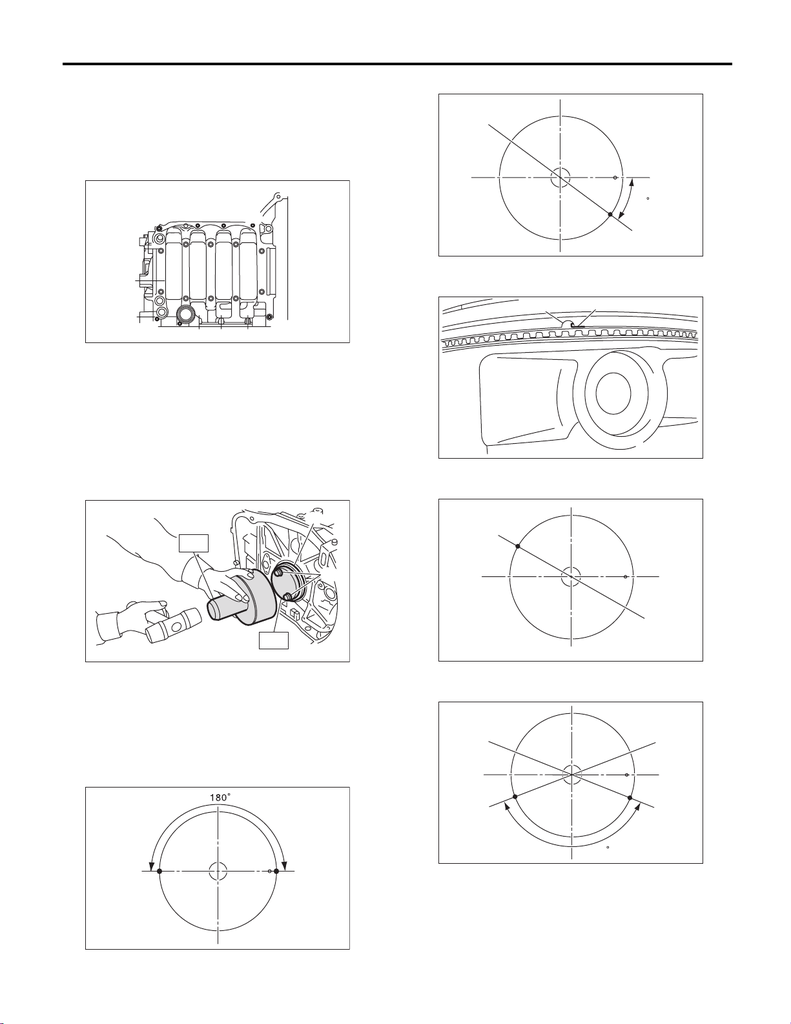

ME(STI)-86

Cylinder Block

MECHANICAL

11) Tighten the 8 mm and 6 mm cylinder block con-

necting bolts on the LH side (A — H) in alphabetical

order.

Tightening torque:

(A) — (G): 25 N·m (2.5 kgf-m, 18.4 ft-lb)

(H): 6.4 N·m (0.7 kgf-m, 4.7 ft-lb)

12) Apply a coat of engine oil to the oil seal inner

periphery and outer periphery, and install the rear

oil seal using ST1 and ST2.

NOTE:

Use a new rear oil seal.

ST1 499597100 CRANKSHAFT OIL SEAL

GUIDE

ST2 499587200 CRANKSHAFT OIL SEAL IN-

STALLER

13) Position the top ring gap at (A) or (B) in the fig-

ure.

14) Position the second ring gap at 180° on the re-

verse side the top ring gap.

15) Position the upper rail gap at (C) in the figure.

16) Align the upper rail spin stopper (E) to the side

hole (D) on the piston.

17) Position the expander gap at (F) in the figure on

the 180° opposite direction of (C).

18) Set the lower rail gap at position (G), located

120° clockwise from (C) in the figure.

NOTE:

• Make sure ring gaps do not face the same direc-

tion.

• Make sure ring gaps are not within the piston

skirt area.

(A) Rear oil seal

(B) Flywheel attachment bolt

ME-00147

(B)

(C)

(D)

(E)

(F)

(G)

(H)

(A)

ME-04998

ST1

ST2

(B)

(A)

ME-04737

(A)

(B)

ME-04738

(C)

25

ME-02471

(E)(D)

ME-04739

(F)

ME-04740

120

(C)

(G)

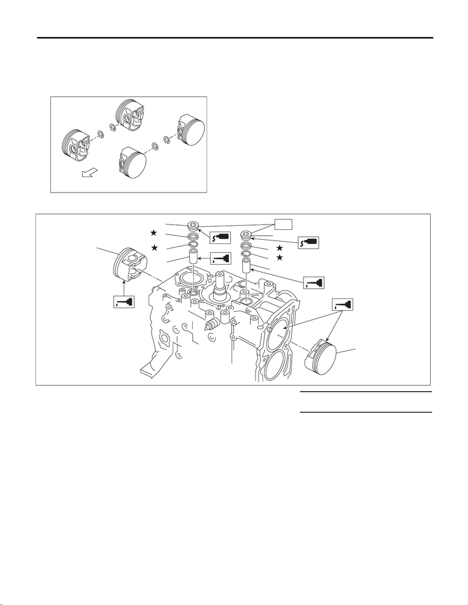

ME(STI)-87

Cylinder Block

MECHANICAL

19) Install the snap ring.

Before positioning the piston on the cylinder block, attach the snap ring in the service hole of the cylinder

block, and the piston hole on the opposite side.

NOTE:

Use new snap rings.

(A) Front side

ME-04764

#4

#3

#2

#1

(A)

(1) Piston (4) Gasket Tightening torque: N·m (kgf-m, ft-lb)

(2) Piston pin (5) Service hole plug T: 70 (7.1, 51.6)

(3) Snap ring

ME-04730

(1)

(1)

(2)

(2)

(3)

(3)

(4)

(4)

(5)

(5)

T

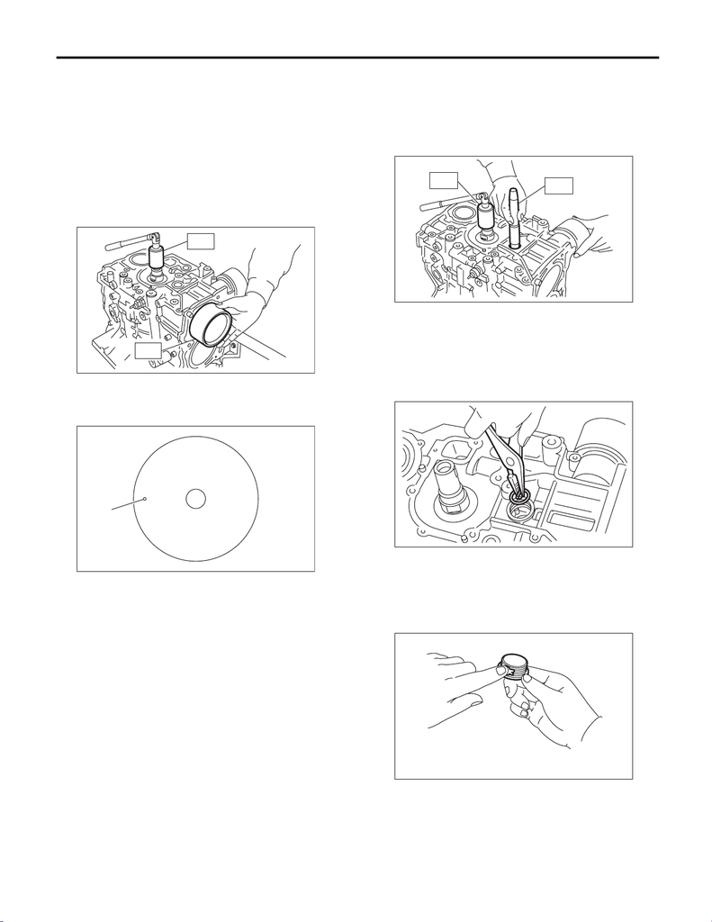

ME(STI)-88

Cylinder Block

MECHANICAL

20) Install the piston.

(1) Set the parts so that the #1 and #2 cylinders

are on the upper side.

(2) Using the ST1, turn the crankshaft so that

#1 and #2 connecting rods are set at bottom

dead center.

ST1 499987500 CRANKSHAFT SOCKET

(3) Apply a coat of engine oil to the pistons and

cylinders and insert pistons in their cylinders us-

ing ST2.

ST2 498747300 PISTON GUIDE

NOTE:

Face the piston front mark towards the front of the

engine.

21) Install the piston pin.

(1) Apply a coat of engine oil to ST3.

(2) Insert ST3 into the service hole to align the

piston pin hole and the connecting rod small

end.

ST3 499017100 PISTON PIN GUIDE

(3) Apply a thin coat of engine oil to piston pin,

and insert the piston pin into piston and con-

necting rod through service hole.

(4) Install the snap ring.

NOTE:

Use new snap rings.

(5) Apply liquid gasket to the threaded portion

of the service hole plug.

Liquid gasket:

THREE BOND 1105 (Part No. 004403010) or

equivalent

(A) Front mark

ME-00157

ST2

ST1

ME-04830

(A)

ME-00158

ST1

ST3

ME-00159

ME-00160

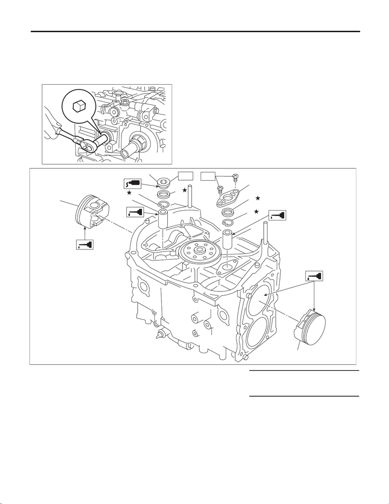

ME(STI)-89

Cylinder Block

MECHANICAL

(6) Install the service hole plug and gasket.

NOTE:

Use a new gasket.

Tightening torque:

70 N·m (7.1 kgf-m, 51.6 ft-lb)

ME-00140

(1) Piston (5) Service hole plug Tightening torque: N·m (kgf-m, ft-lb)

(2) Piston pin (6) Service hole cover T1: 6.4 (0.7, 4.7)

(3) Snap ring (7) O-ring T2: 70 (7.1, 51.6)

(4) Gasket

ME-05040

(2)

(3)

(1)

(2)

(6)

(3)

(7)

(4)

(5)

T2

T1

(1)

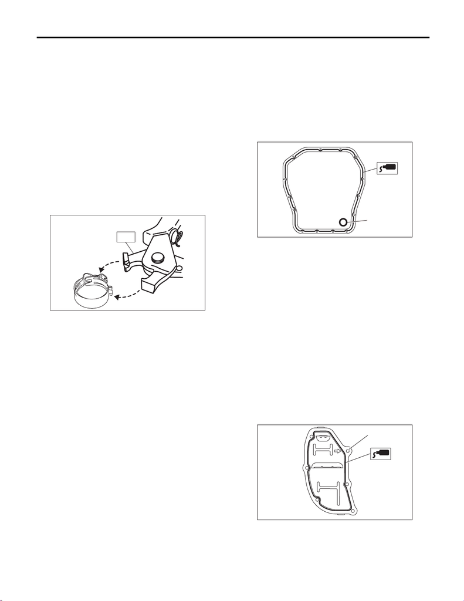

ME(STI)-90

Cylinder Block

MECHANICAL

(7) Set the parts so that the #3 and #4 cylinders

are on the upper side. Following the same pro-

cedures as used for #1 and #2 cylinders, install

the pistons and piston pins.

(8) Install the service hole cover.

NOTE:

Use new O-rings.

Tightening torque:

6.4 N·m (0.7 kgf-m, 4.7 ft-lb)

22) Install the water tank pipe assembly onto the

cylinder block RH.

NOTE:

Use a new clamp for the water tank pipe assembly

clamp, fit the cut out in the ST with the protrusion on

the clamp as shown in the figure, and lock the

clamp.

ST 18353AA000 CLAMP PLIERS

23) Install the baffle plate.

Tightening torque:

6.4 N·m (0.7 kgf-m, 4.7 ft-lb)

24) Install the oil strainer.

NOTE:

Use new O-rings.

Tightening torque:

10 N·m (1.0 kgf-m, 7.4 ft-lb)

25) Tighten the oil strainer stay together with the

baffle plate.

Tightening torque:

6.4 N·m (0.7 kgf-m, 4.7 ft-lb)

26) Apply liquid gasket to the mating surfaces of oil

pan, and install the oil pan.

NOTE:

Install within 5 min. after applying liquid gasket.

Liquid gasket:

THREE BOND 1217G (Part No. K0877Y0100)

or equivalent

Tightening torque:

5 N·m (0.5 kgf-m, 3.7 ft-lb)

27) Apply liquid gasket to the mating surface of oil

separator cover and the threaded portion of bolt (A)

shown in the figure (when reusing the bolt), and

then install the oil separator cover.

NOTE:

• Install within 5 min. after applying liquid gasket.

• Use new oil separator cover.

Liquid gasket:

Mating surface

THREE BOND 1217G

(Part No. K0877Y0100) or equivalent

Bolt thread (A) (when reusing the bolt)

THREE BOND 1324 (Part No. 004403042) or

equivalent

Tightening torque:

6.4 N·m (0.65 kgf-m, 4.7 ft-lb)

28) Install the flywheel. <Ref. to CL-15, INSTALLA-

TION, Flywheel.>

29) Install the clutch disc and cover. <Ref. to CL-

12, INSTALLATION, Clutch Disc and Cover.>

ME-08033

ST

(A) Gasket

LU-02353

(A)

ME-03333

(A)

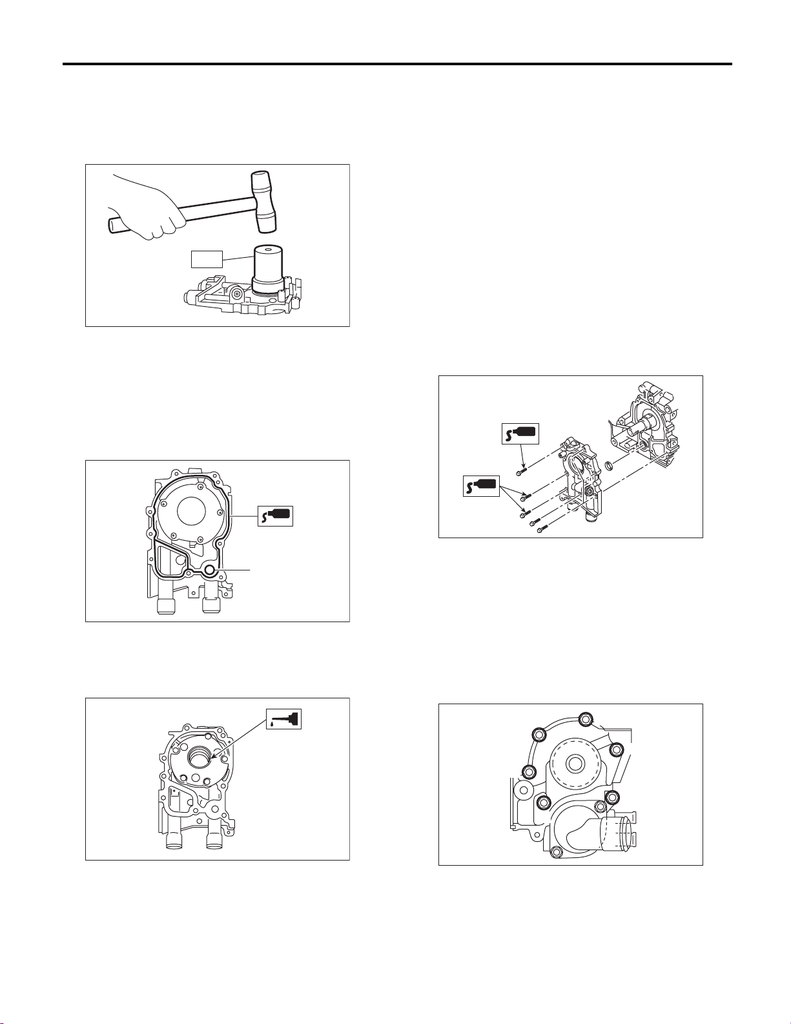

ME(STI)-91

Cylinder Block

MECHANICAL

30) Install the oil pump.

(1) Using the ST, install the front oil seal.

ST 499587100 OIL SEAL INSTALLER

NOTE:

Use a new front oil seal.

(2) Apply liquid gasket to the mating surfaces of

oil pump.

NOTE:

Install within 5 min. after applying liquid gasket.

Liquid gasket:

THREE BOND 1217G (Part No. K0877Y0100)

or equivalent

(3) Apply a thin coat of engine oil to the inside of

front oil seal.

(4) Install the oil pump to cylinder block.

CAUTION:

• Be careful not to damage the front oil seal

during installation.

• Make sure the front oil seal lip is not folded.

NOTE:

• Align the flat surface of oil pump’s inner rotor with

that of crankshaft before installation.

• Use new O-rings.

• Do not forget to assemble O-rings.

(5) Apply liquid gasket to the three bolts thread

shown in figure. (when reusing bolts)

Liquid gasket:

THREE BOND 1324 (Part No. 004403042) or

equivalent

Tightening torque:

6.4 N·m (0.7 kgf-m, 4.7 ft-lb)

31) Install the water pump and gasket.

NOTE:

• When installing the water pump, tighten bolts in

two stages in alphabetical order as shown in the

figure.

• Use a new gasket.

Tightening torque:

First: 12 N·m (1.2 kgf-m, 8.9 ft-lb)

Second: 12 N·m (1.2 kgf-m, 8.9 ft-lb)

32) Install the water by-pass pipe for heater.

Tightening torque:

6.4 N·m (0.7 kgf-m, 4.7 ft-lb)

33) Install the oil cooler. <Ref. to LU(STI)-23, IN-

STALLATION, Engine Oil Cooler.>

(A) O-ring

LU-00021

ST

ME-00165

(A)

ME-00312

ME-04946

ME-04743

(F)

(C)

(A)

(E)

(D)

(B)

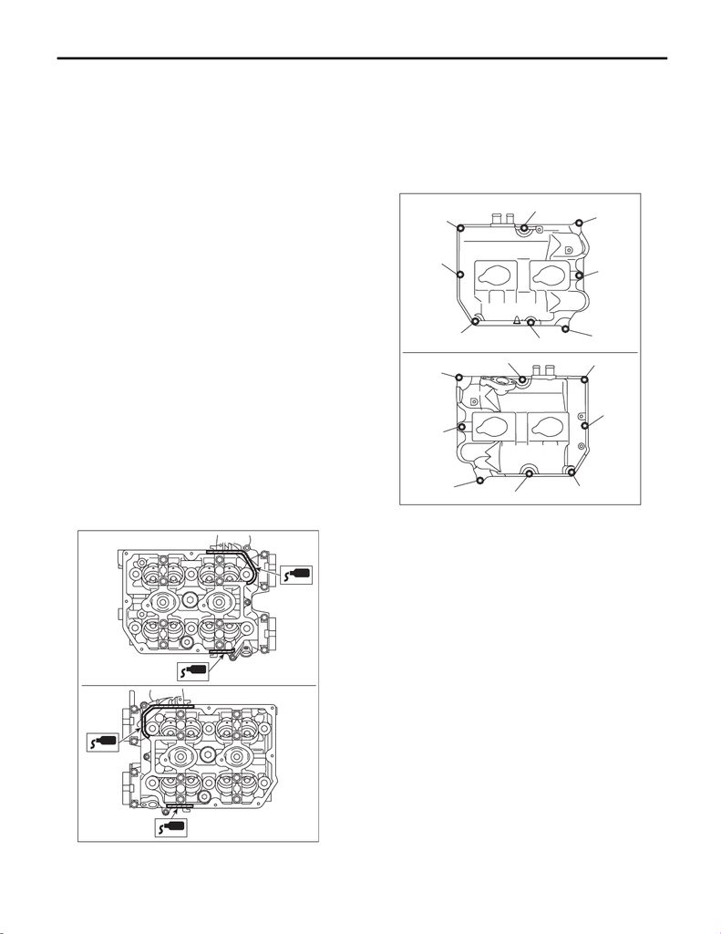

ME(STI)-92

Cylinder Block

MECHANICAL

34) Install the oil filter. <Ref. to LU(STI)-29, IN-

STALLATION, Engine Oil Filter.>

35) Install the cylinder head. <Ref. to ME(STI)-70,

INSTALLATION, Cylinder Head.>

36) Install the camshaft. <Ref. to ME(STI)-64, IN-

STALLATION, Camshaft.>

37) Install the generator and A/C compressor with

their brackets.

Tightening torque:

36 N·m (3.7 kgf-m, 26.6 ft-lb)

38) Install the crank sprocket. <Ref. to ME(STI)-61,

INSTALLATION, Crank Sprocket.>

39) Install the cam sprocket. <Ref. to ME(STI)-60,

INSTALLATION, Cam Sprocket.>

40) Install the timing belt. <Ref. to ME(STI)-53, IN-

STALLATION, Timing Belt.>

41) Adjust the valve clearance. <Ref. to ME(STI)-

29, ADJUSTMENT, Valve Clearance.>

42) Install the rocker cover.

(1) Install the rocker cover gasket to the rocker

cover. (outer section and ignition coil section)

NOTE:

Use a new rocker cover gasket.

(2) Apply liquid gasket to the specified point of

the cylinder head.

NOTE:

Install within 5 min. after applying liquid gasket.

Liquid gasket:

THREE BOND 1217G (Part No. K0877Y0100)

or equivalent

(3) Install the rocker cover onto cylinder heads.

Ensure the gasket is properly positioned during

installation.

(4) Temporarily tighten the rocker cover bolts in

alphabetical order shown in the figure, and then

tighten to specified torque in alphabetical order.

Tightening torque:

6.4 N·m (0.7 kgf-m, 4.7 ft-lb)

ME-05981

ME-05982

(E)

(F)

(H)

(G)

(D),(L)

(A),(I)

(C),(K)

(B),(J)

(B),(J)

(H)

(F)

(C),(K)

(E)

(A),(I)

(D),(L)

(G)

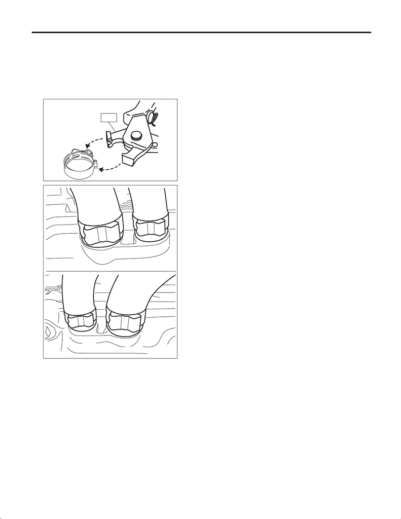

ME(STI)-93

Cylinder Block

MECHANICAL

43) Connect the PCV hose (A) and vacuum hose

(B) to the rocker cover.

NOTE:

Use a new clamp, fit the cut out in the ST with the

protrusion on the clamp as shown in the figure, and

lock the clamp.

ST 18353AA000 CLAMP PLIERS

44) Install the timing belt cover. <Ref. to ME(STI)-

50, INSTALLATION, Timing Belt Cover.>

45) Install the crank pulley. <Ref. to ME(STI)-48,

INSTALLATION, Crank Pulley.>

46) Install the intake manifold. <Ref. to FU(STI)-21,

INSTALLATION, Intake Manifold.>

47) Install the rear side belt. <Ref. to ME(STI)-42,

REAR SIDE BELT, INSTALLATION, V-belt.>

48) Install the engine to the vehicle. <Ref. to

ME(STI)-34, INSTALLATION, Engine Assembly.>

ME-08033

ST

ME-07960

(A)

(A)

(B)

(B)

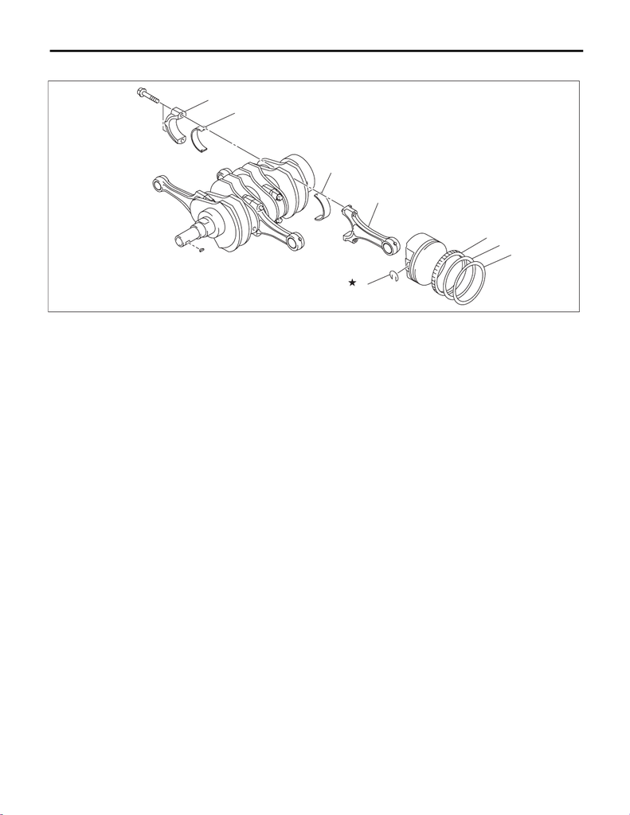

ME(STI)-94

Cylinder Block

MECHANICAL

C: DISASSEMBLY

1) Remove the connecting rod cap.

2) Remove the connecting rod bearing.

NOTE:

Keep the removed connecting rods, connecting rod

caps and bearings in order so that they are kept in

their original combinations/groups, and not mixed

together.

3) Remove the piston rings using piston ring ex-

pander.

4) Remove the oil ring by hand.

NOTE:

Arrange the removed piston rings in proper order,

to prevent confusion.

5) Remove the snap ring.

(1) Top ring (4) Snap ring (6) Connecting rod bearing

(2) Second ring (5) Connecting rod (7) Connecting rod cap

(3) Oil ring

ME-04831

(6)

(6)

(4)

(3)

(2)

(1)

(7)

(5)

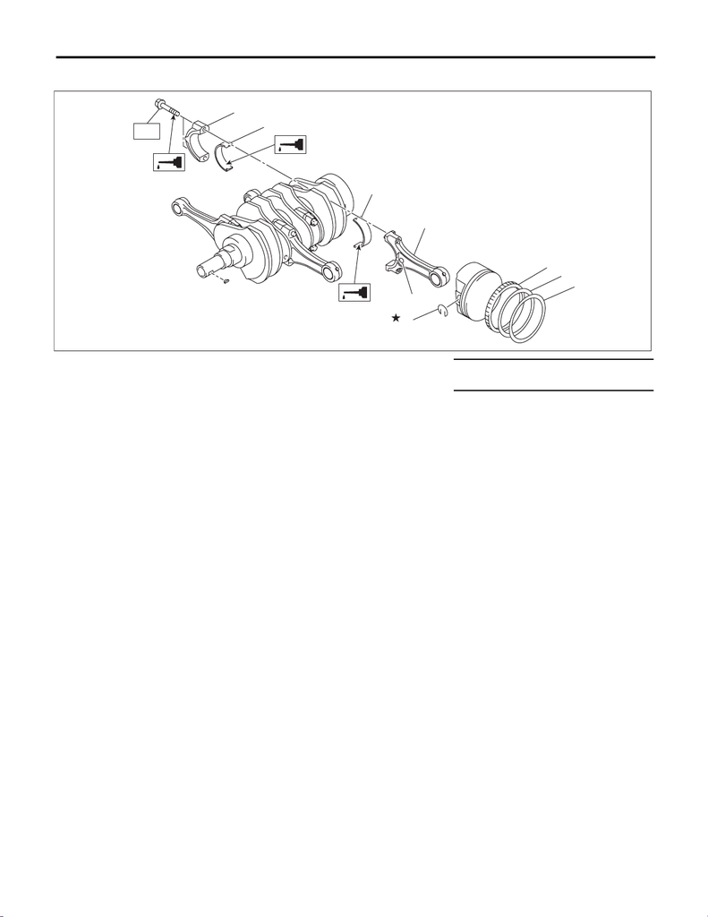

ME(STI)-95

Cylinder Block

MECHANICAL

D: ASSEMBLY

1) Apply engine oil to the surface of the connecting rod bearings, and install the connecting rod bearings on

connecting rods and connecting rod caps.

2) Position each connecting rod with the side with a side mark facing forward, and install it.

3) Attach the connecting rod cap and tighten it with connecting rod bolt. Make sure the arrow on connecting

rod cap faces the front during installation.

NOTE:

• Each connecting rod has its own mating cap. Make sure that they are assembled correctly by checking

their matching number.

• When tightening the connecting rod bolts, apply oil on the threads.

Tightening torque:

52 N·m (5.3 kgf-m, 38.4 ft-lb)

4) Install the oil ring upper rail, expander and lower rail by hand.

5) Install the second ring and top ring using piston ring expander.

NOTE:

Assemble so that the piston ring mark “R” faces the top side of the piston.

(1) Top ring (5) Side mark Tightening torque: N·m (kgf-m, ft-lb)

(2) Second ring (6) Connecting rod T: 52 (5.3, 38.4)

(3) Oil ring (7) Connecting rod bearing

(4) Snap ring (8) Connecting rod cap

ME-04832

(7)

(7)

(4)

(3)

(2)

(1)

(8)

(6)

(5)

T

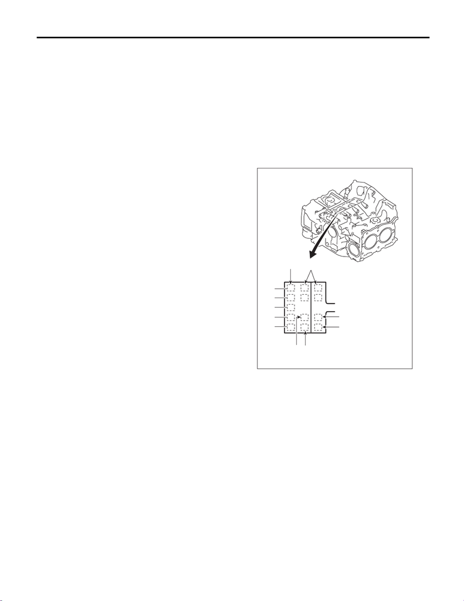

ME(STI)-96

Cylinder Block

MECHANICAL

E: INSPECTION

1. CYLINDER BLOCK

1) Check for cracks or damage. Use liquid pene-

trant tester on the important sections to check for

fissures. Check that there are no marks of gas leak-

ing or water leaking on gasket installing surface.

2) Check the oil passages for clogging.

3) Inspect the cylinder block surface that mates

with cylinder head for warping by using a straight

edge, and correct by grinding if necessary.

Warping limit:

0.025 mm (0.00098 in)

Grinding limit:

0.1 mm (0.004 in)

Standard height of cylinder block:

201.0 mm (7.91 in)

2. CYLINDER AND PISTON

1) The cylinder bore size is stamped on the front

upper face of the cylinder block.

NOTE:

• Measurement should be performed at a temper-

ature of 20°C (68°F).

• Standard sized pistons are classified into two

grades, “A” and “B”. These grades should be used

as guide lines in selecting a standard piston.

Standard diameter:

A: 99.505 — 99.515 mm (3.9175 — 3.9179 in)

B: 99.495 — 99.505 mm (3.9171 — 3.9175 in)

(A) Main journal size mark

(B) Cylinder block (RH) – (LH) combination mark

(C) #1 cylinder bore size mark

(D) #2 cylinder bore size mark

(E) #3 cylinder bore size mark

(F) #4 cylinder bore size mark

ME-00170

#5

#4

#3

#2

#1

(A)

(B)

(F)

(D)

AB

AB

54

54

(C)(E)

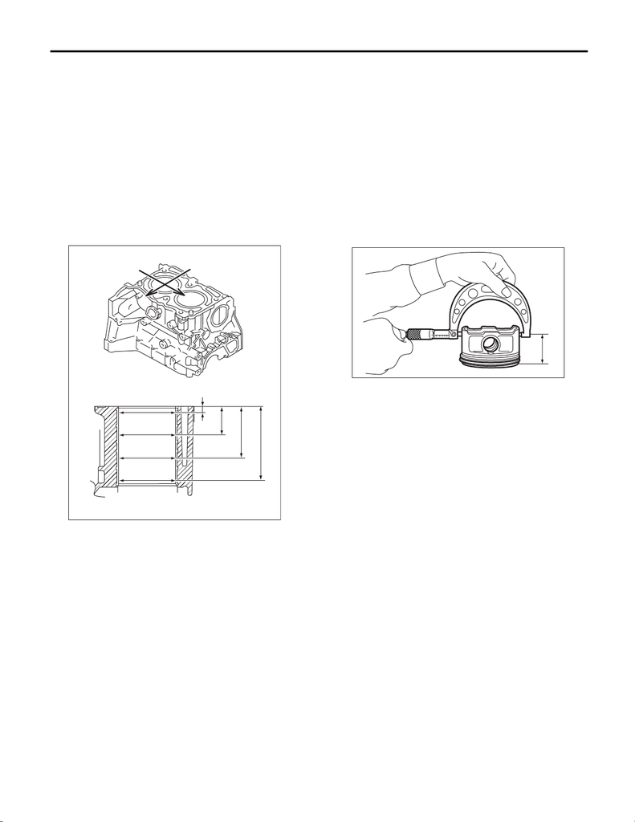

ME(STI)-97

Cylinder Block

MECHANICAL

2) Measure inner diameter of each cylinder.

Measure the inner diameter of each cylinder in both

the thrust and piston pin directions at the heights as

shown in the figure, using a cylinder bore gauge.

NOTE:

Measurement should be performed at a tempera-

ture of 20°C (68°F).

Cylindricality:

Limit

0.015 mm (0.0006 in)

Out-of-roundness:

Limit

0.010 mm (0.0004 in)

3) When the piston is to be replaced due to general

or cylinder wear, select a suitable sized piston by

measuring the piston clearance.

4) Measure outer diameter of each piston.

Measure the outer diameter of each piston at the

height as shown in the figure. (Thrust direction)

NOTE:

Measurement should be performed at a tempera-

ture of 20°C (68°F).

Piston grade point H:

38.2 mm (1.50 in)

Piston outer diameter:

Standard

A: 99.505 — 99.515 mm (3.9175 — 3.9179 in)

B: 99.495 — 99.505 mm (3.9171 — 3.9175 in)

0.25 mm (0.0098 in) oversize

99.745 — 99.765 mm (3.9270 — 3.9278 in)

0.50 mm (0.0197 in) oversize

99.995 — 100.015 mm (3.9368 — 3.9376 in)

5) Calculate the clearance between cylinder and

piston.

NOTE:

Measurement should be performed at a tempera-

ture of 20°C (68°F).

Clearance between cylinder and piston at 20°C

(68°F):

Standard

–0.010 — 0.010 mm (–0.00039 — 0.00039 in)

6) Boring and honing

(1) If any of the measured value of cylindricality,

out-of-roundness or cylinder-to-piston clear-

ance is out of standard or if there is any damage

on the cylinder wall, rebore it to replace with an

oversize piston.

CAUTION:

When any of the cylinders needs reboring, all

other cylinders must be bored at the same time,

and replaced with oversize pistons.

(2) If the cylinder inner diameter exceeds the

limit after boring and honing, replace the cylin-

der block.

NOTE:

Immediately after reboring, the cylinder diameter

may differ from its real diameter due to temperature

rise. Thus, when measuring the cylinder diameter,

wait until it has cooled to room temperature.

Cylinder inner diameter boring limit (diameter):

To 100.005 mm (3.9372 in)

(A) Piston pin direction

(B) Thrust direction

H1: 10 mm (0.39 in)

H2: 45 mm (1.77 in)

H3: 80 mm (3.15 in)

H4: 115 mm (4.53 in)

ME-04734

(A)

(B)

H2

H1

H3

H4

ME-00172

H

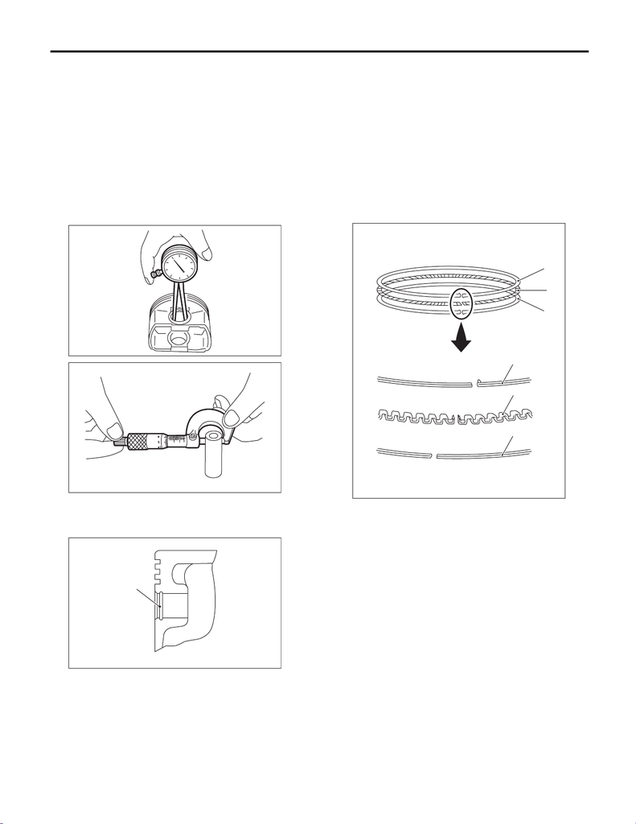

ME(STI)-98

Cylinder Block

MECHANICAL

3. PISTON AND PISTON PIN

1) Check the piston and piston pin for damage,

cracks or wear. Replace if faulty.

2) Check the piston ring groove for wear or dam-

age. Replace if faulty.

3) Make sure that the piston pin can be inserted

into the piston pin hole with a thumb at 20°C (68°F).

Replace if faulty.

Clearance between piston pin hole and piston

pin:

Standard

0.004 — 0.008 mm (0.0002 — 0.0003 in)

4) Check the snap ring installation groove (A) on

the piston for burr. If necessary, remove burr from

the groove so that the piston pin can lightly move.

5) Check the snap ring for distortion, cracks and

wear.

4. PISTON RING

1) If the piston ring is broken, damaged or worn, or

if its tension is insufficient, or when the piston is re-

placed, replace the piston ring with a new part of

the same size as piston.

NOTE:

• The top ring and second ring have the mark to

determine the direction for installing. When install-

ing the ring to piston, face marks to the top side.

• Oil ring consists of the upper rail, expander and

lower rail. When installing oil ring on piston, be

careful of the direction of each rail.

ME-00173

ME-00174

ME-00175

(A)

(A) Upper rail

(B) Expander

(C) Lower rail

ME-02480

(A)

(B)

(C)

(A)

(B)

(C)

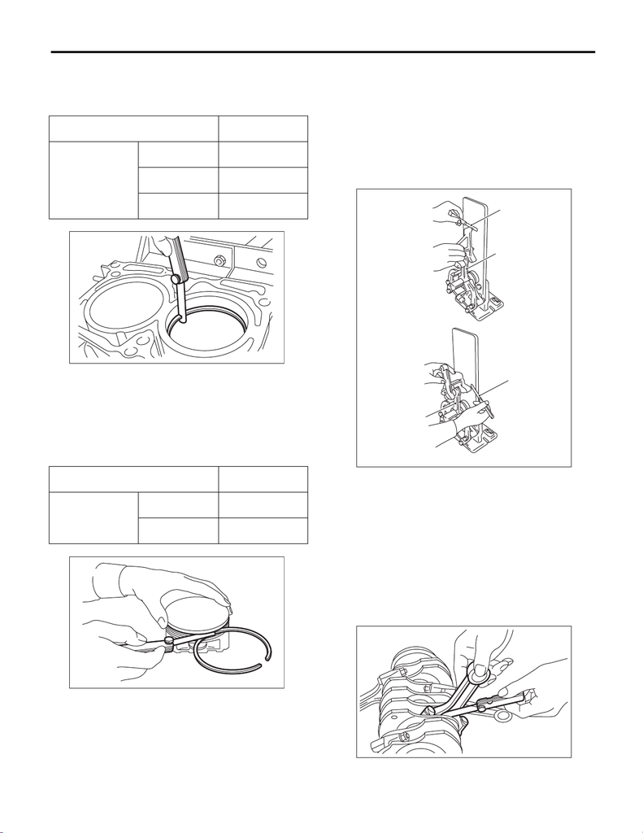

ME(STI)-99

Cylinder Block

MECHANICAL

2) Using the piston, insert the piston ring and oil

ring into the cylinder block so that they are perpen-

dicular to the cylinder wall, and measure the piston

ring gap using a thickness gauge.

3) Fit the piston ring straight into the piston ring

groove, then measure the clearance between pis-

ton ring and piston ring groove with a thickness

gauge.

NOTE:

Before measuring the clearance, clean the piston

ring groove and piston ring.

5. CONNECTING ROD

1) Replace the connecting rod, if the large or small

end thrust surface is damaged.

2) Check for bend or twist using a connecting rod

aligner. Replace the connecting rod if the bend or

twist exceeds the limit.

Limit of bend or twist per 100 mm (3.94 in) in

length:

0.10 mm (0.0039 in)

3) Install the connecting rod with bearings attached

to the crankshaft, and using a thickness gauge,

measure the thrust clearance. If the thrust clear-

ance exceeds the standard or uneven wear is

found, replace the connecting rod.

Connecting rod thrust clearance:

Standard

0.070 — 0.330 mm (0.0028 — 0.0130 in)

4) Inspect the connecting rod bearing for scar,

peeling, seizure, melting, wear, etc.

Standard

mm (in)

Piston ring gap

Top ring

0.23 — 0.28

(0.0091 — 0.0110)

Second ring

0.37 — 0.52

(0.015 — 0.0205)

Oil ring rail

0.20 — 0.50

(0.0079 — 0.0197)

Standard

mm (in)

Clearance between

piston ring and pis-

ton ring groove

Top ring

0.040 — 0.080

(0.0016 — 0.0031)

Second ring

0.030 — 0.070

(0.0012 — 0.0028)

ME-00177

ME-00178

(A) Thickness gauge

(B) Connecting rod

(A)

(A)

(B)

(B)

ME-05475

ME-00180

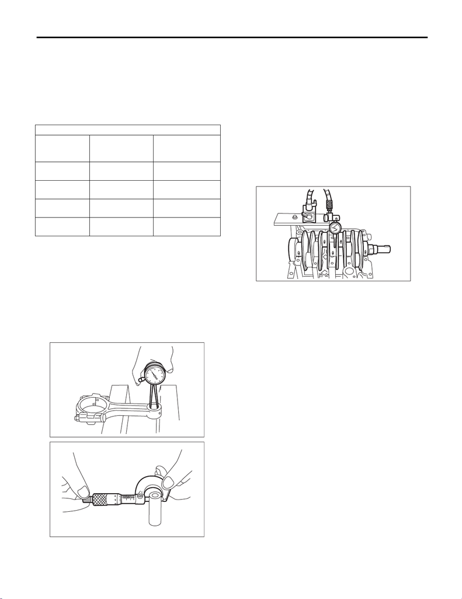

ME(STI)-100

Cylinder Block

MECHANICAL

5) Measure the oil clearance on each connecting

rod bearing using plastigauge. If any oil clearance

is not within the standard, replace the defective

bearing with a new part of standard size or under-

size as necessary.

Connecting rod oil clearance:

Standard

0.017 — 0.045 mm (0.0007 — 0.0018 in)

6) Inspect the bushing at connecting rod small end,

and replace the connecting rod if it is worn or dam-

aged.

7) Measure the piston pin clearance at connecting

rod small end. If the measured value is not within

the standard, replace the connecting rod and piston

pin as a set.

Clearance between piston pin and bushing:

Standard

0 — 0.022 mm (0 — 0.0009 in)

6. CRANKSHAFT AND CRANKSHAFT

BEARING

1) Clean the crankshaft completely, and check it for

cracks using liquid penetrant tester. If defective, re-

place the crankshaft.

2) Measure warping of the crankshaft. If it exceeds

the limit, correct or replace it.

NOTE:

If a suitable V-block is not available, using just the

#1 and #5 crankshaft bearings on cylinder block,

position the crankshaft on cylinder block. Then,

measure the crankshaft bend using a dial gauge.

Crankshaft bend limit:

0.035 mm (0.0014 in)

Unit: mm (in)

Bearing

Bearing size

(Thickness at cen-

ter)

Outer diameter of

crank pin

Standard

1.490 — 1.506

(0.0587 — 0.0593)

51.976 — 52.000

(2.0463 — 2.0472)

0.03 (0.0012)

Undersize

1.504 — 1.512

(0.0592 — 0.0595)

51.954 — 51.970

(2.0454 — 2.0461)

0.05 (0.0020)

Undersize

1.514 — 1.522

(0.0596 — 0.0599)

51.934 — 51.950

(2.0447 — 2.0453)

0.25 (0.0098)

Undersize

1.614 — 1.622

(0.0635 — 0.0639)

51.734 — 51.750

(2.0368 — 2.0374)

ME-00181

ME-00174

ME-00183

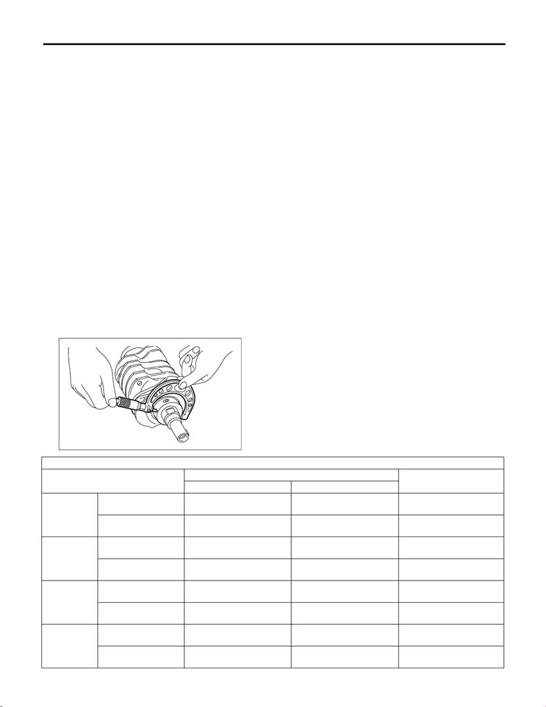

ME(STI)-101

Cylinder Block

MECHANICAL

3) Inspect the crank journal and crank pin for wear.

If they are not within the standard, replace the bear-

ing with a suitable (undersize) one, and replace or

grind to correct the crankshaft as necessary. When

grinding the crank journal or crank pin, finish them

to the specified dimensions according to the under-

size bearing to be used.

Crank pin:

Cylindricality

Limit

0.006 mm (0.0002 in)

Out-of-roundness

Limit

0.005 mm (0.0002 in)

Grinding limit (dia.)

To 51.734 mm (2.0368 in)

Crank journal:

Cylindricality

Limit

0.006 mm (0.0002 in)

Out-of-roundness

Limit

0.005 mm (0.0002 in)

Grinding limit (dia.)

To 59.742 mm (2.3520 in)

ME-00184

Unit: mm (in)

Crank journal diameter

Crank pin outer diameter

#1, #3 #2, #4, #5

Standard

Journal O.D.

59.984 — 60.008

(2.3616 — 2.3625)

59.984 — 60.008

(2.3616 — 2.3625)

51.976 — 52.000

(2.0463 — 2.0472)

Bearing size

(Thickness at center)

1.998 — 2.015

(0.0787 — 0.0793)

2.000 — 2.017

(0.0787 — 0.0794)

1.490 — 1.506

(0.0587 — 0.0593)

0.03 (0.0012)

Undersize

Journal O.D.

59.962 — 59.978

(2.3607 — 2.3613)

59.962 — 59.978

(2.3607 — 2.3613)

51.954 — 51.970

(2.0454 — 2.0461)

Bearing size

(Thickness at center)

2.017 — 2.020

(0.0794 — 0.0795)

2.019 — 2.022

(0.0795 — 0.0796)

1.504 — 1.512

(0.0592 — 0.0595)

0.05 (0.0020)

Undersize

Journal O.D.

59.942 — 59.958

(2.3599 — 2.3605)

59.942 — 59.958

(2.3599 — 2.3605)

51.934 — 51.950

(2.0447 — 2.0453)

Bearing size

(Thickness at center)

2.027 — 2.030

(0.0798 — 0.0799)

2.029 — 2.032

(0.0799 — 0.0800)

1.514 — 1.522

(0.0596 — 0.0599)

0.25 (0.0098)

Undersize

Journal O.D.

59.742 — 59.758

(2.3520 — 2.3527)

59.742 — 59.758

(2.3520 — 2.3527)

51.734 — 51.750

(2.0368 — 2.0374)

Bearing size

(Thickness at center)

2.127 — 2.130

(0.0837 — 0.0839)

2.129 — 2.132

(0.0838 — 0.0839)

1.614 — 1.622

(0.0635 — 0.0639)

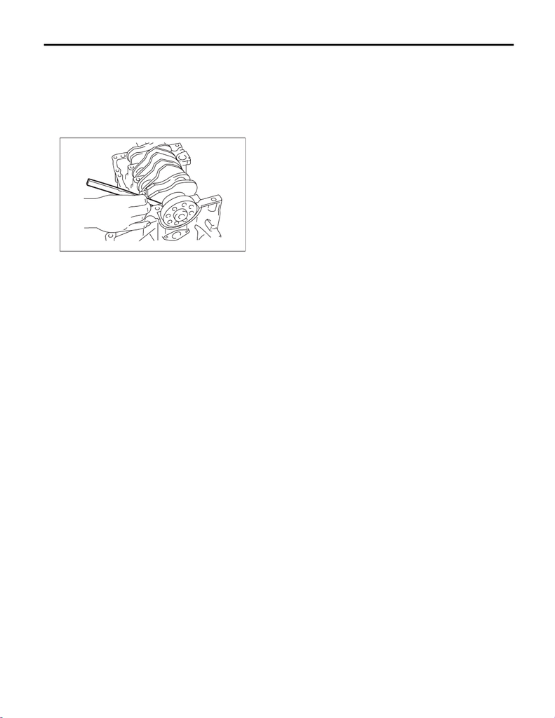

ME(STI)-102

Cylinder Block

MECHANICAL

4) Use a thickness gauge to measure the thrust

clearance of crankshaft at #5 crank journal bearing.

If clearance exceeds the standard, replace the

bearing.

Crankshaft thrust clearance:

Standard

0.030 — 0.115 mm (0.0012 — 0.0045 in)

5) Inspect individual crankshaft bearings for signs

of flaking, seizure, melting and wear.

6) Measure the oil clearance on each crankshaft

bearing using plastigauge. If the measured value is

out of standard, replace the defective bearing with

an undersize one, and replace or grind to correct

the crankshaft as necessary.

Crankshaft oil clearance:

Standard

0.010 — 0.030 mm (0.00039 — 0.0012 in)

ME-00322